# 03 Database - Part 1

Designed for Rachel

Harry Lu, dl947@cornell.edu

Jun/12/2022

HOME

# 1 Basics

- Type of data
  - Structured data
  - Unstructured data
- Information
  - Processed data
- Metadata

# 2 Reference Book

- **Modern Database Management 12th Edition**
  - Jeffrey Hoffer (Author), Ramesh Venkataraman (Author), Heikki Topi (Author)

# 3 Database

## 3.1 What is Database?

- Organized collection of logically related data

## 3.2 Why is better than traditional file processing

- Solved data redundancy
- Save space
- Easy to maintain
- Easy to share

# 4 Database Management System (DBMS)

## 4.1 Key Advantages

- Program-data independence
- Improved data consistency, quality, sharing
- Enforcement of standards

## 4.2 Elements of the Database Approach

- Data model
- Entity
- Relationship
- Relational database

## 4.3 Data Model

- Enterprise Data Model: high-level entities and relationships for the organization

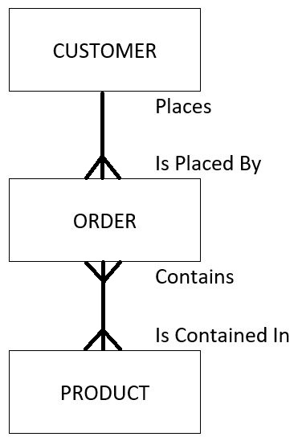

- Project Data Model: more detailed view, matching data structure in database or data warehouse

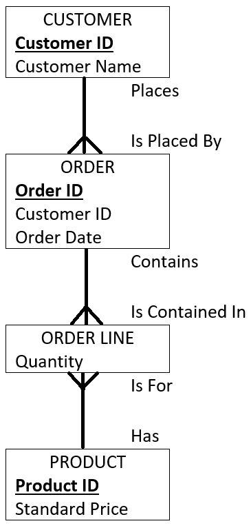

## 4.4 Entity

- A person, a place, an object, an event or a concept about which people want to maintain data. It is:
  - expressed as noun
  - composed of attributes

## 4.5 Relationship

- The association between the entities is described with a verb or verb phrase
- Associates the entities:
  - is represented by a line or a crow’s foot
  - is usually one-to-many (1:M) or many-to-many (M:N)

## 4.6 Relational Database

- A collection of tables (relations)
- All data relationships are represented by common values in the related tables

## 4.7 Primary/Foreign Key Pair

- `Customer ID` from `CUSTOMER` and `ORDER`

# 5 Modeling the Rules of the Organization

## 5.1 Business Rules

- Define or constrain some aspect of the business
- Guide to design the database relations

## 5.2 Purpose of Data Modeling

- Represent business
- Govern data and enforce the rule through database technology

## 5.3 Naming Data Object

- Meaningful, self-documenting
- Unique
- Readable
- Repeatable

## 5.4 Entity-Relationship (E-R) Model

- A logical representation of the data
- Use **entities** for categories of data and **relationships** for associations between entities
- Represent by E-R diagram

# 6 Modeling Entities and Attributes

## 6.1 Design Entity

- Have many instances in the database
  - Student: Student A, Student B, …
- Have multiple attributes
  - Student: Name, Gender, Student #, …

## 6.2 Entity Type vs. Entity Instance

- Entity type
  - singular name
  - capital letters
  - normally a database table
- Entity instance
  - a single occurrence of an entity
  - normally a row in a table
- Example
  - Entity type: `EMPLOYEE`

| Attributes | Attribute Data Type |
| --- | --- |
| Employee Number | `CHAR(10)` |
| Name | `CHAR(25)` |
| Address | `CHAR(30)` |
| City | `CHAR(20)` |
| State | `CHAR(2)` |
| Zip Code | `CHAR(9)` |
| Date Hired | `DATE` |
| Birth Date | `DATE` |

## 6.3 Identifiers (Keys)

- Identifier (Primary Key): an attribute (or combination of attributes) that uniquely **identifies individual** instances of an entity
- Properties
  - unique
  - not null
  - not change in value

**Copyright © 2022 Harry Lu. All rights reserved.**